# Final Independent Project

Marisa Mackie

2023-05-09

## Introduction

This project is related to my Master’s Thesis project:

**Mapping chemical stimuli to their cognate neurons in *Pristionchus pacificus* via genetically encoded calcium indicators**

I work with nematode (microscopic roundworm) species *Pristionchus pacificus* and am interested in studying their amphid neurons, which are responsible for the sensing of chemicals in their environment–that is, odorants and tastants. There are 12 pairs of these amphid neurons, however, it is unknown which neurons specifically correspond to particular volatile odors or water-soluble tastants. My goal is to map various chemical stimuli to their cognate neurons.

To do this, I have used genetically-encoded calcium indicators (GECIs) (i.e., GCaMP) to measure neuron response to chemical stimuli in real time. Neuron response is measured and ultimately calculated as **percent change in fluorescence intensity (df/f) over time**.

### Purpose:

I want to visualize df/f over time in the form of line plots, where any peaks along the line would indicate a large change in fluorescence (and therefore, neural activity). I would hope to see peaks that correspond to the times I administered the chemical stimulus to the worm.

I want to visualize:

- df/f for each individual worm
- Average df/f of each treatment group

## Libraries

These are the necessary libraries we will need to load.

```r
library(here)
library(tidyverse)
library(tidytext)
```

## Data

Data is stored in the **data** folder. This data was collected and stored in a *.log* file, in the form of 9 comma-delimited columns. The data is organized in folders in this order:

*worm strain & stimulant* –> *tracking Journal* –> *worm ID* –> .log file

During analysis, we will be using *for loops* to iterate through each of these folders & grab the worm data.

## Functions

For the purposes of this project, I have created a handful of functions that we will need to use for data analysis:

**dff()** The entire project is based around the measurement of percent change in fluorescence in the neuron over time. This is called *delta f / f* (a.k.a *dff*).

Therefore, we require a function to calculate dff from our raw fluorescence data.

```r
## Function for calculating df/f (% change in fluorescence)
dff <- function(data) {
  # sets baseline fluorescence
  f0 <- mean(data[10:40]) # averages fluorescence data from frame 10-40 (1-4s)
  # calculates df/f as a percentage
  dff <- ((data - f0)/f0)*100
  # returns dff
  return(dff)
}
```

**e_to_num()** This function is due to an issue I ran into while analyzing fluorescence data. The fluorescence data is stored in scientific notation, e.g. *1.2345e+008*. However, R reads this as a *string* due to the “e” and “+”, but we need R to read it as a *numeric* so we can use it for mathematical calculations (i.e., calculating dff).

Therefore, we require a function to convert this character into a double. In doing so, we would convert it from scientific notation to its expanded form.

```r
## Function to convert strings of scientific notation containing "e" (i.e., 1.234e+005) to numeric in expanded form (double)
e_to_num <- function(string) {
  # finds first instance of "e" in the string, subsets everything before it & converts it to a numeric (double)
  value <- as.numeric(substring(string, 1, unlist(gregexpr("e", string))[1]))
  # finds first instance of "+" in the string, subsets everything after it & converts it to a numeric (double)
  # note: this number is the exponent, so we will set 10^exponent
  exponent <- 10^(as.numeric(str_sub(string, unlist(gregexpr("\\+", string))[1]+1, str_length(string))))
  # multiplies value by the 10^n exponent
  expanded_num <- value*exponent
  # returns numeric (double) of original string in expanded form
  return(expanded_num)
}
```

## Part 1

Part 1 has multiple objectives that will be split into sub-parts:

- **Iterate through the folders & get the data (.log files)**
- **Clean data & convert to clean .csv**
- **Calculate dff values for each individual worm**
- **Plot dff values for each individual worm**

### Part 1a - Iterate through folders & get the data

As previously mentioned, the data is stored in nested folders as such:

*worm strain & stimulant –> tracking Journal –> worm ID –> .log file*

Therefore, we need a for-loop to iterate through each of these.

The basic outline would look something like this:

```r
## Iterates through each stimulant folder
#for (i in 1:length(stim_folders)){

  ## Iterates through each JNL folder
  #for (j in 1:length(jnl_folders)){

    ## Iterates through each worm folder
    #for (k in 1:length(worm_folders)){

    ## } # ends iteration through worm folders

  ## } # ends iteration through JNL folders

## } # ends iteration through stim_folders
```

So we set up the necessary paths for each one:

```r
# points to worm strain + stimulant folder on the computer
stim_path <- here("IndependentProject_Mackie", "data", "GCaMP_data")
# lists all folders in that path
stim_folders <- dir(path = stim_path)

# Iterates through each stimulant folder
for (i in 1:length(stim_folders)){

  # points to JNL folder on the computer
  jnl_path <- here("IndependentProject_Mackie", "data", "GCaMP_data", stim_folders[i])
  # lists all JNL folders in that path
  jnl_folders <- dir(path = jnl_path)

  # Iterates through each JNL folder within the current stimulant folder
  for (j in 1:length(jnl_folders)){
    # points to worm folder on the computer
    worm_path <- here("IndependentProject_Mackie", "data", "GCaMP_data", stim_folders[i], jnl_folders[j])
    # lists all worm folders in that path
    worm_folders <- dir(path = worm_path)

    # Iterates through each worm folder within the current JNL folder
    for (k in 1:length(worm_folders)){

    } # ends iteration through worm folders

  } # ends iteration through JNL folders

} # ends iteration through stim_folders
```

Now that we have made it to the logfiles, we can read them in:

```r
### within worm-folder iteration ###

# points to the location of tracked worm data (logfiles) on the computer
      logfile_path <- here("IndependentProject_Mackie", "data", "GCaMP_data", stim_folders[i], jnl_folders[j], worm_folders[k])
      # lists all logfiles in that path (contains ".log")
      logfiles <- dir(path = logfile_path, pattern = ".log")

      # reads in current logfile into rawdata
      rawdata <- read_log(here("IndependentProject_Mackie","data", "GCaMP_data", stim_folders[i],jnl_folders[j],worm_folders[k],logfiles))
```

Here’s one example of the raw data from one of the .log files:

```r
glimpse(rawdata)
```

```
## Rows: 1,799
## Columns: 9
## $ X1 <dbl> 2, 3, 4, 5, 6, 7, 8, 9, 10, 11, 12, 13, 14, 15, 16, 17, 18, 19, 20,…
## $ X2 <dbl> 100, 200, 301, 400, 500, 600, 700, 800, 900, 1000, 1100, 1200, 1300…
## $ X3 <chr> "2.56996e+008,", "2.52869e+008,", "2.49897e+008,", "2.47145e+008,",…
## $ X4 <chr> "5.02262e+007,", "4.90528e+007,", "4.83303e+007,", "4.78552e+007,",…
## $ X5 <chr> "3.07222e+008,", "3.01922e+008,", "2.98227e+008,", "2.95e+008,", "2…
## $ X6 <dbl> 11580, 11430, 11337, 11258, 11200, 11109, 11063, 11070, 10980, 1096…
## $ X7 <dbl> 4337.33, 4291.58, 4263.06, 4250.77, 4230.43, 4203.62, 4190.86, 4067…
## $ X8 <dbl> 1241, 1242, 1242, 1242, 1242, 1243, 1243, 1241, 1243, 1244, 1244, 1…
## $ X9 <dbl> 1055, 1055, 1055, 1056, 1056, 1056, 1056, 1049, 1056, 1056, 1057, 1…
```

Now that the logfiles are being read in with each iteration, while we’re here, we can begin to clean the data.

### Part 1b - Clean data & convert to clean .csv

It makes sense to do this while still in the for-loops because it will do the cleaning to *each* logfile.

```r
### within worm-folder iteration ###

# reads in current logfile into rawdata
      rawdata <- read_log(here("IndependentProject_Mackie","data", "GCaMP_data", stim_folders[i],jnl_folders[j],worm_folders[k],logfiles))

      wormdata <- rawdata %>%
        # adds column for stimulant and JNL type
        mutate(stim_jnl = paste(stim_folders[i],jnl_folders[j], sep = "_"),
               # renames default column names (Xn) to specified variable names
               frame = rawdata$X1,
               time_s = (rawdata$X2)/1000, # converts time in ms to s
               fluor = rawdata$X3,
               .keep = "used") # only keeps mutated columns
```

Here is an example of what one of our clean data looks like:

```r
glimpse(wormdata)
```

```
## Rows: 1,799
## Columns: 4
## $ stim_jnl <chr> "odr7p_NH4Br_JNL_10off_120on_50off", "odr7p_NH4Br_JNL_10off_1…
## $ frame    <dbl> 2, 3, 4, 5, 6, 7, 8, 9, 10, 11, 12, 13, 14, 15, 16, 17, 18, 1…
## $ time_s   <dbl> 0.100, 0.200, 0.301, 0.400, 0.500, 0.600, 0.700, 0.800, 0.900…
## $ fluor    <chr> "2.56996e+008,", "2.52869e+008,", "2.49897e+008,", "2.47145e+…
```

### Part 1c - Calculate dff values for each individual worm

Next, here is where I did my **calculations for dff** which required me to use the **dff()** function I showed earlier.

However, I also ran into an issue of needing to convert strings to numerics before I could successfully calculate dff, which is why I also created the **e_to_num()** function.

```r
### within worm-folder iteration ###

# For fluor column, removes commas and converts values from sci notation (chr) to expanded form (dbl)
      wormdata <- wormdata %>%
        mutate(fluor = str_replace_all(fluor, "\\,",""),
               fluor = e_to_num(fluor)) %>%
        # adds column for calculating dff
        mutate(dff = dff(fluor))
```

Here is where I then converted my cleaned & dff-calcuated data into a *.csv* file and saved it to my **data folder** to use later.

Since this is still being iterated, it created one .csv file for *each* logfile.

```r
### within worm-folder iteration ###

# converts wormdata to csv and saves to clean_csv folder within data folder, naming it based on stimulant, JNL, and worm ID
      write_csv(wormdata, here("IndependentProject_Mackie", "data", "clean_csv", paste(stim_folders[i],jnl_folders[j],logfiles, sep = "_")))
```

### Part 1d - Plot dff values for each individual worm

Still within the iteration, I created plots of dff over time for *each individual worm*.

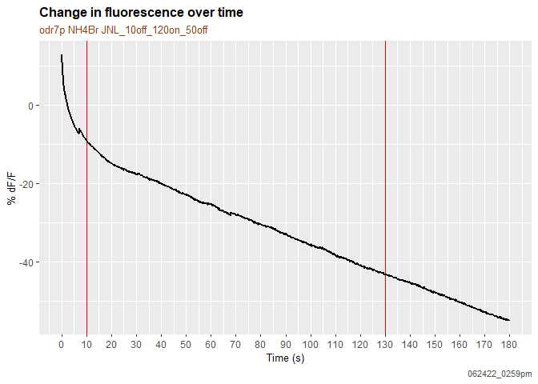

```r
### within worm-folder iteration ###

# generates plot of % df/f over time in s
      ggplot()+

        # axis scales by 10
        scale_x_continuous(breaks = seq(from = 0, to = 180, by=10))+

        # adds red vertical line to notable timepoints for stimulant ON & OFF
        geom_vline(xintercept = 10, color = "red")+
        geom_vline(xintercept = 130, color = "red")+

        # specifies line plot, & size/color of line
        geom_line(data = wormdata,
                  mapping = aes(x = time_s, y = dff),
                  color = "black", linewidth = 1)+

        # specifies plot labels
        labs(x = "Time (s)",
             y = "% dF/F",
             title = "Change in fluorescence over time",
             subtitle = paste(str_replace_all(stim_folders[i], "_", " "), jnl_folders[j]),
             caption = worm_folders[k])+

        # specifies color and size of plot elements
        theme(plot.title = element_text(size = 12, face = "bold"),
              plot.subtitle = element_text(size = 10, color = "saddlebrown"),
              plot.caption = element_text(size = 8, color = "gray30"),
              axis.title = element_text(size = 10))
```

```r
      # saves plot to output folder, and names it by worm folder name
      ggsave(here("IndependentProject_Mackie","output","individual_dff",paste("plot",stim_folders[i],jnl_folders[j],worm_folders[k],".png", sep = "-")),
             width = 6, height = 6)
```

Lastly, I made sure to close each loop.

Here is *Part1* all together:

```r
# pre-allocates a dataframe to hold information for convenience later
# 4 columns, but we will append more rows later
size_mat <- data.frame(matrix(ncol = 5))

# worm_num is the current worm being analyzed overall
worm_num = 0

# points to worm strain + stimulant folder on the computer
stim_path <- here("IndependentProject_Mackie", "data", "GCaMP_data")
# lists all folders in that path
stim_folders <- dir(path = stim_path)

# Iterates through each stimulant folder
for (i in 1:length(stim_folders)){

  # points to JNL folder on the computer
  jnl_path <- here("IndependentProject_Mackie", "data", "GCaMP_data", stim_folders[i])
  # lists all JNL folders in that path
  jnl_folders <- dir(path = jnl_path)

  # Iterates through each JNL folder within the current stimulant folder
  for (j in 1:length(jnl_folders)){
    # points to worm folder on the computer
    worm_path <- here("IndependentProject_Mackie", "data", "GCaMP_data", stim_folders[i], jnl_folders[j])
    # lists all worm folders in that path
    worm_folders <- dir(path = worm_path)

    # Iterates through each worm folder within the current JNL folder
    for (k in 1:length(worm_folders)){

      # adds +1 to worm count
      worm_num = worm_num + 1

      # points to the location of tracked worm data (logfiles) on the computer
      logfile_path <- here("IndependentProject_Mackie", "data", "GCaMP_data", stim_folders[i], jnl_folders[j], worm_folders[k])
      # lists all logfiles in that path (contains ".log")
      logfiles <- dir(path = logfile_path, pattern = ".log")

      # reads in current logfile into rawdata
      rawdata <- read_log(here("IndependentProject_Mackie","data", "GCaMP_data", stim_folders[i],jnl_folders[j],worm_folders[k],logfiles))

      wormdata <- rawdata %>%
        # adds column for stimulant and JNL type
        mutate(stim_jnl = paste(stim_folders[i],jnl_folders[j], sep = "_"),
               # renames default column names (Xn) to specified variable names
               frame = rawdata$X1,
               time_s = (rawdata$X2)/1000, # converts time in ms to s
               fluor = rawdata$X3,
               .keep = "used") # only keeps mutated columns

      # For fluor column, removes commas and converts values from sci notation (chr) to expanded form (dbl)
      wormdata <- wormdata %>%
        mutate(fluor = str_replace_all(fluor, "\\,",""),
               fluor = e_to_num(fluor)) %>%
        # adds column for calculating dff
        mutate(dff = dff(fluor))

      # converts wormdata to csv and saves to clean_csv folder within data folder, naming it based on stimulant, JNL, and worm ID
      write_csv(wormdata, here("IndependentProject_Mackie", "data", "clean_csv", paste(stim_folders[i],jnl_folders[j],logfiles, sep = "_")))

      # generates plot of % df/f over time in s
      ggplot()+

        # axis scales by 10
        scale_x_continuous(breaks = seq(from = 0, to = 180, by=10))+

        # adds red vertical line to notable timepoints for stimulant ON & OFF
        geom_vline(xintercept = 10, color = "red")+
        geom_vline(xintercept = 130, color = "red")+

        # specifies line plot, & size/color of line
        geom_line(data = wormdata,
                  mapping = aes(x = time_s, y = dff),
                  color = "black", linewidth = 1)+

        # specifies plot labels
        labs(x = "Time (s)",
             y = "% dF/F",
             title = "Change in fluorescence over time",
             subtitle = paste(str_replace_all(stim_folders[i], "_", " "), jnl_folders[j]),
             caption = worm_folders[k])+


        # specifies color and size of plot elements
        theme(plot.title = element_text(size = 12, face = "bold"),
              plot.subtitle = element_text(size = 10, color = "saddlebrown"),
              plot.caption = element_text(size = 8, color = "gray30"),
              axis.title = element_text(size = 10))

      # saves plot to output folder, and names it by worm folder name
      ggsave(here("IndependentProject_Mackie","output","individual_dff",paste("plot",stim_folders[i],jnl_folders[j],worm_folders[k],".png", sep = "-")),
             width = 6, height = 6)

      # number of frames is the number of rows within wormdata
      frames <- nrow(wormdata)

      # dataframe to store time information (to use for plotting later)
      time_data <- wormdata$time_s

    } # ends iteration through worm folders

    # adds column names to size_mat
    colnames(size_mat) <- c("frames","stim_jnl","worms_jnl","worm_num","jnl_start")
    # appends rows to size_mat
    size_mat[nrow(size_mat) + 1,] = c(frames,
                                      paste(stim_folders[i],jnl_folders[j],sep = "_"), # stimulant + jnl
                                      k, # final worm of each journal (= worms per journal)
                                      worm_num, # worm count (= total worms up to that journal)
                                      worm_num - k + 1) # starting worm for each jnl

  } # ends iteration through JNL folders

} # ends iteration through stim_folders

# drop first row (Nas) from size_mat
size_mat <- drop_na(size_mat)
```

Although, during this iteration, I created some helpful variables to help me later on during analysis.

For example:

```r
glimpse(size_mat)
```

```
## Rows: 2
## Columns: 5
## $ frames    <chr> "1799", "1799"
## $ stim_jnl  <chr> "odr7p_Bcary_5percent_JNL_10off_120on_50off", "odr7p_NH4Br_J…
## $ worms_jnl <chr> "4", "3"
## $ worm_num  <chr> "4", "7"
## $ jnl_start <chr> "1", "5"
```

The next 3 parts will all be related to producing the **Average dff** plots.

For this, we will use the clean .csv files that we created!

This is the approach:

1. Gather all individual dff values from the csv files into a single dataframe called **dff_all**
2. **Average** dff values by Stimulant + JNL and store them in *avg_all*
3. **Plot Average dff!**

## Part 2 - Gather dff values into dff_all

We previously calculated dff for each worm and stored it into our clean csv files.

Therefore, to grab those dff values, we must iterate through each csv file.

```r
# points to location of csv file on the computer
csv_path <- here("IndependentProject_Mackie", "data", "clean_csv")
# lists all .csv files in that path
csvfiles <- dir(path = csv_path)

# pre-allocates a dataframe to store all dff values
dff_all <- data.frame(matrix(nrow = frames, ncol = length(csvfiles)))
# adds column names as dff{n}
colnames(dff_all) <- c(paste("dff_worm",(1:length(csvfiles)),sep = ""))

# Iterates through each csv file (i.e., for each worm)
for (l in 1:length(csvfiles)){

  # reads in csv files
  csv_data <- read_csv(here("IndependentProject_Mackie", "data", "clean_csv", csvfiles[l]))

  # stores dff column into dff_all
  dff_all[l] <- csv_data$dff
}
```

Here are all the dff values for each worm:

```r
glimpse(dff_all)
```

```
## Rows: 1,799
## Columns: 7
## $ dff_worm1 <dbl> 7.78421419, 5.50019255, 3.89903325, 3.39011396, 2.81392763, …
## $ dff_worm2 <dbl> 7.51252268, 5.64086815, 4.22507746, 3.39734039, 2.62651173, …
## $ dff_worm3 <dbl> 19.86658078, 14.93156216, 11.46215748, 9.74996576, 7.4428012…
## $ dff_worm4 <dbl> 30.32544393, 23.40312824, 19.23385301, 16.16684304, 15.23879…
## $ dff_worm5 <dbl> 0.7500382, -0.8659774, -1.8515417, -1.5657475, -1.6588823, -…
## $ dff_worm6 <dbl> 25.3349649, 19.9867124, 18.2970356, 16.1368218, 14.7754106, …
## $ dff_worm7 <dbl> 12.92793365, 11.11446736, 9.80852556, 8.59925509, 7.75250211…
```

## Part 3 - Average dff values by Stimulant + Journal

Now that we have dff values all stored in dff_all, we can now take the averages of those based on the Stimulant + JNL combination.

To do this, we can use *size_mat* to iterate through the Stimulant + JNLs (treatments), which only requires one for-loop.

*(As opposed to previously, where we iterated through 3 sets of folders and therefore needed 3 nested for-loops. Creating the .csv files was useful for reducing the amount of separate iterations we must do to access our data.)*

```r
# pre-allocates a dataframe to store all average dff values (averaged by journal)
# 2 columns because there are 2 unique stim + jnl combinations
avg_all <- data.frame(matrix(nrow = frames, ncol = nrow(size_mat)))
# adds column names as stim_jnl{n}
colnames(avg_all) <- c(paste("stim_jnl",(1:nrow(size_mat)),sep = ""))

# iterates over each row in size_mat (i.e., m = the current stim_jnl)
for (m in 1:nrow(size_mat)){

  # if first stim_jnl, starts with 1st worm
  ifelse(m == 1, start_worm <-  1,
         # else, starts with 1st worm of the current journal
         start_worm <- size_mat$jnl_start[m])

  # ending worm = final worm of current stim_jnl
  end_worm <- size_mat$worm_num[m]

  # calculates averages across rows, only for worms that correspond to the current stim_jnl (removes NAs)
  # stores this in column of avg_all corresponding to current stim_jnl
  avg_all[m] <- rowMeans(dff_all[,start_worm:end_worm])

} # ends iteration for each jnl (row in size_mat)
```

Here are the Average dff values (for each treatment group = Stimulant + JNL).

```r
glimpse(avg_all)
```

```
## Rows: 1,799
## Columns: 2
## $ stim_jnl1 <dbl> 16.37219039, 12.36893777, 9.70503030, 8.17606579, 7.03050944…
## $ stim_jnl2 <dbl> 13.004312271, 10.078400766, 8.751339813, 7.723443160, 6.9563…
```

## Part 4 - Plot Average dff

Here is where the Average dff (per treatment group) was plotted. To do this, we have once again used the handy variable *size_mat* to help us iterate through the Stimulant + JNLs, without having to iterate through 3 different folders!

Note: This likely could have been done in the previous iteration, but I chose to do it separately for ease of understanding.

```r
# pre-allocates dataframe to hold only the x & y values for plotting
plot_data <- data.frame(matrix(nrow = frames, ncol = 2))
# column names
colnames(plot_data) <- c("x","y")

# iterates for each journal (# of rows in size_mat)
for (n in 1:nrow(size_mat)){

  # updates plot_data with appropriate data
  plot_data <- plot_data %>%
    mutate(x = time_data, # assigns time data to x column
           y = avg_all[,n]) # assigns current column of avg_all to y column

  # generates plot of average % df/f over time in s
  ggplot(plot_data)+

    # axis scales by 10
    scale_x_continuous(breaks = seq(from = 0, to = 180, by = 10))+

    # adds red vertical line to notable timepoints for stimulant ON & OFF
    geom_vline(xintercept = 10, color = "red")+
    geom_vline(xintercept = 130, color = "red")+

    # specifies line plot, & size/color of line
    geom_line(mapping = aes(x = x,
                            y = y),
              color = "blue", linewidth = 2)+

    # specifies plot labels
    labs(x = "Time (s)",
         y = "% dF/F",
         title = "Average Change in fluorescence over time",
         subtitle = size_mat$stim_jnl[n])+ # current stimulant + jnl


    # specifies color and size of plot elements
    theme(plot.title = element_text(size = 12, face = "bold"),
          plot.subtitle = element_text(size = 10, color = "saddlebrown"),
          plot.caption = element_text(size = 8, color = "gray30"),
          axis.title = element_text(size = 10))

  # saves plot to output folder, and names it by worm folder name
  ggsave(here("IndependentProject_Mackie","output","average_dff",paste("plot",size_mat$stim_jnl[n],".png", sep = "-")),
         width = 6, height = 6)

} # ends iteration
```

Here is one of the two Average dff plots I have so far! (One for each treatment group)

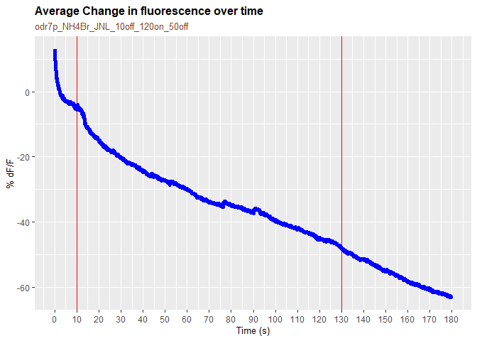

## All together now!

Here is the *entire* project, where all of these parts work together to produce my desired data visualizations!

```r
#### Load Libraries ####-----------------------------------------------
library(tidyverse)
library(here)
library(tidytext)

#### Functions ####----------------------------------------------------

## Function to convert strings of scientific notation containing "e" (i.e., 1.234e+005) to numeric in expanded form (double)
e_to_num <- function(string) {
  # finds first instance of "e" in the string, subsets everything before it & converts it to a numeric (double)
  value <- as.numeric(substring(string, 1, unlist(gregexpr("e", string))[1]))
  # finds first instance of "+" in the string, subsets everything after it & converts it to a numeric (double)
  # note: this number is the exponent, so we will set 10^exponent
  exponent <- 10^(as.numeric(str_sub(string, unlist(gregexpr("\\+", string))[1]+1, str_length(string))))
  # multiplies value by the 10^n exponent
  expanded_num <- value*exponent
  # returns numeric (double) of original string in expanded form
  return(expanded_num)
}

## Function for calculating df/f (% change in fluorescence)
dff <- function(data) {
  # sets baseline fluorescence
  f0 <- mean(data[10:40]) # averages fluorescence data from frame 10-40 (1-4s)
  # calculates df/f as a percentage
  dff <- ((data - f0)/f0)*100
  # returns dff
  return(dff)
}

#### Analysis ####-----------------------------------------------------
#### Part 1 - Get data, convert to clean csv, calculate dff, plot individual dff ####----------

# pre-allocates a dataframe to hold information for convenience later
# 4 columns, but we will append more rows later
size_mat <- data.frame(matrix(ncol = 5))

# worm_num is the current worm being analyzed overall
worm_num = 0

# points to worm strain + stimulant folder on the computer
stim_path <- here("IndependentProject_Mackie", "data", "GCaMP_data")
# lists all folders in that path
stim_folders <- dir(path = stim_path)

# Iterates through each stimulant folder
for (i in 1:length(stim_folders)){

  # points to JNL folder on the computer
  jnl_path <- here("IndependentProject_Mackie", "data", "GCaMP_data", stim_folders[i])
  # lists all JNL folders in that path
  jnl_folders <- dir(path = jnl_path)

  # Iterates through each JNL folder within the current stimulant folder
  for (j in 1:length(jnl_folders)){
    # points to worm folder on the computer
    worm_path <- here("IndependentProject_Mackie", "data", "GCaMP_data", stim_folders[i], jnl_folders[j])
    # lists all worm folders in that path
    worm_folders <- dir(path = worm_path)

    # Iterates through each worm folder within the current JNL folder
    for (k in 1:length(worm_folders)){

      # adds +1 to worm count
      worm_num = worm_num + 1

      # points to the location of tracked worm data (logfiles) on the computer
      logfile_path <- here("IndependentProject_Mackie", "data", "GCaMP_data", stim_folders[i], jnl_folders[j], worm_folders[k])
      # lists all logfiles in that path (contains ".log")
      logfiles <- dir(path = logfile_path, pattern = ".log")

      # reads in current logfile into rawdata
      rawdata <- read_log(here("IndependentProject_Mackie","data", "GCaMP_data", stim_folders[i],jnl_folders[j],worm_folders[k],logfiles))

      wormdata <- rawdata %>%
        # adds column for stimulant and JNL type
        mutate(stim_jnl = paste(stim_folders[i],jnl_folders[j], sep = "_"),
               # renames default column names (Xn) to specified variable names
               frame = rawdata$X1,
               time_s = (rawdata$X2)/1000, # converts time in ms to s
               fluor = rawdata$X3,
               .keep = "used") # only keeps mutated columns

      # For fluor column, removes commas and converts values from sci notation (chr) to expanded form (dbl)
      wormdata <- wormdata %>%
        mutate(fluor = str_replace_all(fluor, "\\,",""),
               fluor = e_to_num(fluor)) %>%
        # adds column for calculating dff
        mutate(dff = dff(fluor))

      # converts wormdata to csv and saves to clean_csv folder within data folder, naming it based on stimulant, JNL, and worm ID
      write_csv(wormdata, here("IndependentProject_Mackie", "data", "clean_csv", paste(stim_folders[i],jnl_folders[j],logfiles, sep = "_")))

      # generates plot of % df/f over time in s
      ggplot()+

        # axis scales by 10
        scale_x_continuous(breaks = seq(from = 0, to = 180, by=10))+

        # adds red vertical line to notable timepoints for stimulant ON & OFF
        geom_vline(xintercept = 10, color = "red")+
        geom_vline(xintercept = 130, color = "red")+

        # specifies line plot, & size/color of line
        geom_line(data = wormdata,
                  mapping = aes(x = time_s, y = dff),
                  color = "black", linewidth = 1)+

        # specifies plot labels
        labs(x = "Time (s)",
             y = "% dF/F",
             title = "Change in fluorescence over time",
             subtitle = paste(str_replace_all(stim_folders[i], "_", " "), jnl_folders[j]),
             caption = worm_folders[k])+


        # specifies color and size of plot elements
        theme(plot.title = element_text(size = 12, face = "bold"),
              plot.subtitle = element_text(size = 10, color = "saddlebrown"),
              plot.caption = element_text(size = 8, color = "gray30"),
              axis.title = element_text(size = 10))

      # saves plot to output folder, and names it by worm folder name
      ggsave(here("IndependentProject_Mackie","output","individual_dff",paste("plot",stim_folders[i],jnl_folders[j],worm_folders[k],".png", sep = "-")),
             width = 6, height = 6)

      # number of frames is the number of rows within wormdata
      frames <- nrow(wormdata)

      # dataframe to store time information (to use for plotting later)
      time_data <- wormdata$time_s

    } # ends iteration through worm folders

    # adds column names to size_mat
    colnames(size_mat) <- c("frames","stim_jnl","worms_jnl","worm_num","jnl_start")
    # appends rows to size_mat
    size_mat[nrow(size_mat) + 1,] = c(frames,
                                      paste(stim_folders[i],jnl_folders[j],sep = "_"), # stimulant + jnl
                                      k, # final worm of each journal (= worms per journal)
                                      worm_num, # worm count (= total worms up to that journal)
                                      worm_num - k + 1) # starting worm for each jnl

  } # ends iteration through JNL folders

} # ends iteration through stim_folders

# drop first row (Nas) from size_mat
size_mat <- drop_na(size_mat)

"Part 1 complete!
Clean csv files generated (see data)
Individual dff plots generated (see outputs)"
```

```
## [1] "Part 1 complete!\nClean csv files generated (see data)\nIndividual dff plots generated (see outputs)"
```

```r
#### Part 2 - Gather dff values into dff_all ####-------------

# points to location of csv file on the computer
csv_path <- here("IndependentProject_Mackie", "data", "clean_csv")
# lists all .csv files in that path
csvfiles <- dir(path = csv_path)

# pre-allocates a dataframe to store all dff values
dff_all <- data.frame(matrix(nrow = frames, ncol = length(csvfiles)))
# adds column names as dff{n}
colnames(dff_all) <- c(paste("dff_worm",(1:length(csvfiles)),sep = ""))

# Iterates through each csv file (i.e., for each worm)
for (l in 1:length(csvfiles)){

  # reads in csv files
  csv_data <- read_csv(here("IndependentProject_Mackie", "data", "clean_csv", csvfiles[l]))

  # stores dff column into dff_all
  dff_all[l] <- csv_data$dff
}

"Part 2 complete!
Gathered all dff values into dff_all."
```

```
## [1] "Part 2 complete!\nGathered all dff values into dff_all."
```

```r
#### Part 3 - Average dff values by Stimulant + Journal & Plot them! ####-------------

# pre-allocates a dataframe to store all average dff values (averaged by journal)
# 2 columns because there are 2 unique stim + jnl combinations
avg_all <- data.frame(matrix(nrow = frames, ncol = nrow(size_mat)))
# adds column names as stim_jnl{n}
colnames(avg_all) <- c(paste("stim_jnl",(1:nrow(size_mat)),sep = ""))

# iterates over each row in size_mat (i.e., m = the current stim_jnl)
for (m in 1:nrow(size_mat)){

  # if first stim_jnl, starts with 1st worm
  ifelse(m == 1, start_worm <-  1,
         # else, starts with 1st worm of the current journal
         start_worm <- size_mat$jnl_start[m])

  # ending worm = final worm of current stim_jnl
  end_worm <- size_mat$worm_num[m]

  # calculates averages across rows, only for worms that correspond to the current stim_jnl (removes NAs)
  # stores this in column of avg_all corresponding to current stim_jnl
  avg_all[m] <- rowMeans(dff_all[,start_worm:end_worm])

} # ends iteration for each jnl (row in size_mat)

"Part 3 complete!
Average dff calculated and stored in avg_all"
```

```
## [1] "Part 3 complete!\nAverage dff calculated and stored in avg_all"
```

```r
#### Part 4 - Plotting Average dff ####-------------

# pre-allocates dataframe to hold only the x & y values for plotting
plot_data <- data.frame(matrix(nrow = frames, ncol = 2))
# column names
colnames(plot_data) <- c("x","y")

# iterates for each journal (# of rows in size_mat)
for (n in 1:nrow(size_mat)){

  # updates plot_data with appropriate data
  plot_data <- plot_data %>%
    mutate(x = time_data, # assigns time data to x column
           y = avg_all[,n]) # assigns current column of avg_all to y column

  # generates plot of average % df/f over time in s
  ggplot(plot_data)+

    # axis scales by 10
    scale_x_continuous(breaks = seq(from = 0, to = 180, by = 10))+

    # adds red vertical line to notable timepoints for stimulant ON & OFF
    geom_vline(xintercept = 10, color = "red")+
    geom_vline(xintercept = 130, color = "red")+

    # specifies line plot, & size/color of line
    geom_line(mapping = aes(x = x,
                            y = y),
              color = "blue", linewidth = 2)+

    # specifies plot labels
    labs(x = "Time (s)",
         y = "% dF/F",
         title = "Average Change in fluorescence over time",
         subtitle = size_mat$stim_jnl[n])+ # current stimulant + jnl


    # specifies color and size of plot elements
    theme(plot.title = element_text(size = 12, face = "bold"),
          plot.subtitle = element_text(size = 10, color = "saddlebrown"),
          plot.caption = element_text(size = 8, color = "gray30"),
          axis.title = element_text(size = 10))

  # saves plot to output folder, and names it by worm folder name
  ggsave(here("IndependentProject_Mackie","output","average_dff",paste("plot",size_mat$stim_jnl[n],".png", sep = "-")),
         width = 6, height = 6)

} # ends iteration

"Part 4 complete!
Average dff plots generated! (see outputs)"
```

```
## [1] "Part 4 complete!\nAverage dff plots generated! (see outputs)"
```

```r
"Done!"
```

```
## [1] "Done!"
```

## Future notes

Although this does what I need and works pretty well, a project can always be improved upon!

Here are some things I’d like to work on & add to this project in the future:

- Plot individual worm dff & average dff together. This makes it easier to see how close individual worms are to each other, and how the average compares to each worm in the sample.
- Making the code “future-proof.” I want to be able to add new data to it without worrying about my code breaking. The data I am working with have different journal programs, and therefore different numbers of frames and times. I would need to make adjustments so that my data can be plotted successfully for all of my different experimental conditions.
- Additional tidying & efficiency in general.
- Other calculations I could make & other ways to visualize my data.